# Midterm exam for XB_0082 (Introduction to Python Programming)

## 23rd of October

This assignment consists of 6 questions. The maximum number of points you can score in this part of the exam by answering the questions correctly is 90 points. Please use the cells below the questions to enter your answers and work within the designated `TODO` areas.

#### For grading:

| Exercise | 1.1 | 1.2 | 1.3 | 1.4 | 2 | 3 | Other |
| --- | --- | --- | --- | --- | --- | --- | --- |
| **Max score** | **10** | **10** | **20** | **15** | **20** | **15** | **-10** |
| Score |  |  |  |  |  |  |  |

Students must not modify this table. If so, this will be considered an attempt of fraud 👀.

🔔 Enter your full name and VUnet ID (3 letters, 3 numbers). If you do not fill in the latter or you input different data, 10 points will be subtracted automatically.

```python
Full_name = "YOUR NAME"

VUnet_ID = "ABC123"
```

### Important Reminder

Follow all coding conventions defined on the Python Coding Standard document. In particular:

- All **function** and **variable** definitions must have *type hints*, and functions must have proper *docstrings*.
- Use comments **only** if the code really needs additional explanation. Remember, not all lines of code should be commented.
- Variable, parameters, and function names must be meaningful.
- For all tasks, you can define additional functions to improve the code readability.

🔔 Code cells containing syntax errors will automatically give you zero points (0) in that task.

## Preliminaries

Run the cell below. This cell will import additional modules providing additional Python functionality.

```python
# Run this cell to import needed functionality and types
from typing import Dict, List, Any
import string
import re
```

## Task 1

In this exercise, you will work with a database of famous Latin American artists. The database is represented as a dictionary, where the keys are the artist names (strings), and the values are dictionaries containing the following details:

- country: The artist's country of origin.
- age: The artist's age.
- artworks: A list of famous artworks by the artist.

You will be given a dictionary called `artists`, which contains information about multiple Latin American artists. Your task is to complete the program that interacts with this data and performs several operations.

```python
artists: Dict[str, Any] = {
    "Frida Kahlo": {"country": "Mexico", "age": 47, "artworks": ["The Two Fridas", "Self-Portrait with Thorn Necklace"]},
    "Diego Rivera": {"country": "Mexico", "age": 70, "artworks": ["Man at the Crossroads", "Detroit Industry Murals"]},
    "Fernando Botero": {"country": "Colombia", "age": 91, "artworks": ["The Death of Pablo Escobar", "Mona Lisa, Age Twelve"]},
    "Tarsila do Amaral": {"country": "Brazil", "age": 86, "artworks": ["Abaporu", "Antropofagia"]},
    "Wifredo Lam": {"country": "Cuba", "age": 79, "artworks": ["The Jungle", "The Eternal Present"]}
}
```

## Task 1.1 (10 points)

Write a function `find_artist(artists, artist_name)` that takes the artists dictionary and an `artist_name` (a string) as input. The function should return the details of the specified artist (a dictionary), or throw an exception with the message `Artist not found` if the artist is not in the dictionary.

Example 1:

`find_artist(artists, "Frida Kahlo")`

Output:

`{'country': 'Mexico', 'age': 47, 'artworks': ['The Two Fridas', 'Self-Portrait with Thorn Necklace']}`

Example 2:

`find_artist(artists, "Pablo Picasso")`

Output:

`"Artist not found"`

```python
#// BEGIN_TODO
















#// END_TODO
try:
      find_artist(artists, "Frida Kahlo")
except Exception as error:
      print(error)
```

## Task 1.2 (10 points)

Write a function `artwork_with_longest_name(artists)` that takes the artists dictionary as input and returns the name of the artwork with the longest name. The results must exactly follow the structure presented below. If two artworks have the same number of characters you can return either. If the input dictionary of artists is empty, you must throw an exception with the message `The artists dictionary is empty`.

Example: `artist_with_longest_name(artists)`

Output: `The artwork with the longest title is "Self-Portrait with Thorn Necklace" (33 characters) made by Frida Kahlo`

Example: `artist_with_longest_name({})`

Output: `The artists dictionary is empty`

```python
#// BEGIN_TODO
















#// END_TODO

try:
      print(artwork_with_longest_name(artists))
except Exception as error:
      print(error)
```

## Task 1.3 (20 points)

In this exercise, you will continue working with the Latin American artists database. Your task is to write a function that takes in the artists' data and returns a list of artists whose ages are prime numbers.

Write a function `find_prime_age_artists(artists)` that takes the artists dictionary as input and returns a list of artist names whose ages are prime numbers.

*Definition of Prime Number:* A prime number is a number greater than 1 that has no positive divisors other than 1 and itself. The first few prime numbers are 2, 3, 5, 7, 11, 13, 17, 19, 23, 29, 31, and so on.

Example:

`print(find_prime_age_artists(artists))`

Output:

`["Frida Kahlo", "Wifredo Lam"]`

```python
#// BEGIN_TODO
















#// END_TODO
find_prime_age_artists(artists)
```

## Task 1.4 (15 points)

Write a function `artworks_by_country(artists)` that takes the artists dictionary as input and returns a new dictionary where each key is a country name and the value is a list of artist names from that country along with their respective artworks.

Expected output:

```
{
    "Mexico": [
        {"artist": "Frida Kahlo", "artworks": ["The Two Fridas", "Self-Portrait with Thorn Necklace"]},
        {"artist": "Diego Rivera", "artworks": ["Man at the Crossroads", "Detroit Industry Murals"]}
    ],
    "Colombia": [
        {"artist": "Fernando Botero", "artworks": ["The Death of Pablo Escobar", "Mona Lisa, Age Twelve"]}
    ],
    "Brazil": [
        {"artist": "Tarsila do Amaral", "artworks": ["Abaporu", "Antropofagia"]}
    ],
    "Cuba": [
        {"artist": "Wifredo Lam", "artworks": ["The Jungle", "The Eternal Present"]}
    ]
}
```

```python
from typing import Dict
#// BEGIN_TODO
















#// END_TODO
artworks_by_country(artists)
```

## Task 2 -- Text Analysis: Lou Reed's Songs (20 points)

Lou Reed was born Lewis Allan Reed on March 2, 1942, in Brooklyn, New York. He grew up in a middle-class Jewish family and showed an early interest in music and literature. Reed's childhood was marked by a passion for rock and roll, influenced by artists such as Buddy Holly, Elvis Presley, and the Doo-Wop groups of the time. He attended Syracuse University, where he studied English Literature and took courses in creative writing and music.

He is known for his influential contributions to rock music. He was the founder of the band The Velvet Underground, and his solo career produced some of the most critically acclaimed music of the 20th century. His lyrics often explore themes of urban life, love, addiction, and the human experience.

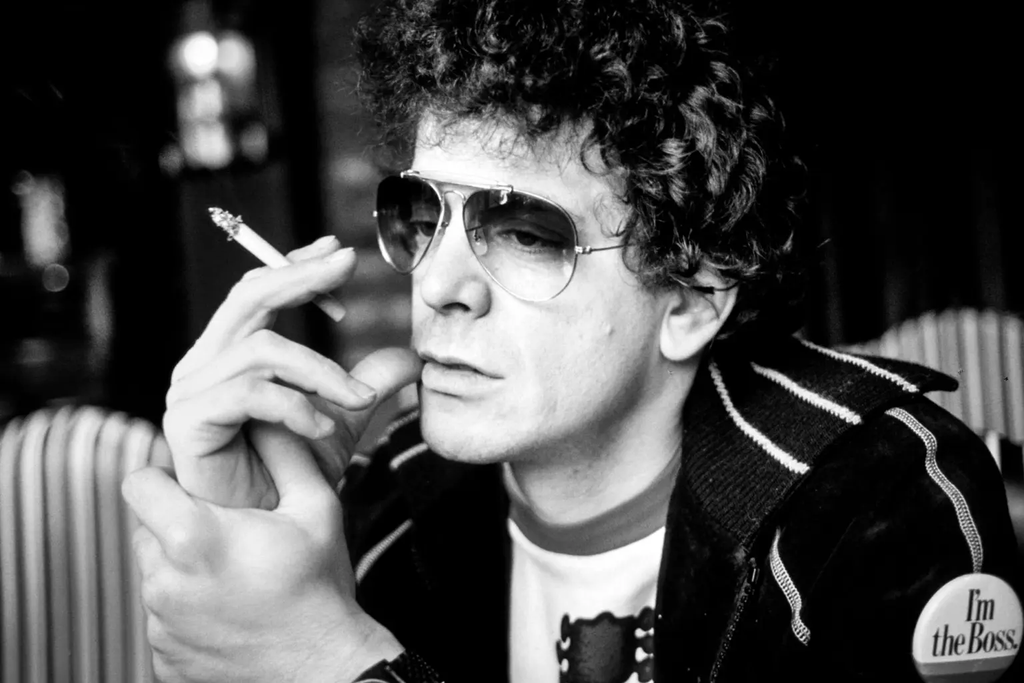

*Lou Reedin 1972 Gijsbert Hanekroot/Redferns*

**Files** You will be provided with two text files:

- `song1.txt`: Contains the lyrics of "Perfect Day".
- `song2.txt`: Contains the lyrics of "Walk on the Wild Side".

**Requirements**

- **Read the lyrics from the text files**: Load the contents of both `song1.txt` and `song2.txt` into your Python program.
- **Define a function**: Create a function `most_frequent_words(text_1: str, text_2: str n: int)` that takes the paths of two file texts (`text_1` and `text_2`) and an integer `n` as parameters, and returns the `n` most frequent words in the text, along with their frequency counts.
- **Preprocess the text**: Convert all text to lowercase, remove punctuation (e.g., `"`, `,`, and `.`), and split the text into words.
- **Count the frequency of each word**: count how often each word appears in the lyrics.
- **Return the top 10 words**: Return a list of dictionaries, containing a word as a key and its frequency count as values.

*Hint*: To solve this problem might be useful to use the strategy used in assignment 1, where you first define:

1. the **problem** or **question** to be answered;
2. the **inputs** of your solution;
3. the **output** of your solution, and;
4. the **algorithm** to come up with an answer.

*Reminder* 👀: To be able to test with the right files, you must upload these two files (`song1.txt` and `song2.txt`) to Jupyter.

Output:

```
do-doo: 40
a: 23
the: 20
doo: 20
do-do-doo: 20
on: 13
and: 10
she: 10
said: 10
hey: 10
```

```python
def sort_dictionary_words(input_dct: Dict[str, int]) -> List[List]:
      """
      This function takes as input a histogram of words and returns a sorted list of words
      :param input dictionary containing words and occurences.
      :returns sorted list of words in descending order
      """
      return sorted(input_dct.items(), key=lambda item: item[1], reverse=True)

def read_files(file_path:str) -> str:
      """
      This function reads a file given the path.
      :param file_path path to the file
      :returns the content of the file received as parameter.
      """
      with open(file_path, 'r') as file:
            return file.read()

#// BEGIN_TODO




















#// END_TODO

for word, count in most_frequent_words("song1.txt", "song2.txt", 10):
    print(f"{word}: {count}")
```

## Task 3. String Cleaning (15 points)

Let's assume that you're managing a database, and your database is storing customers' names. However, because of the way we use these names, they must follow specific rules.

For this exercise, you have to create a function called `standardize_name` that takes a name as input and checks if the name complies with the rules. If the name does not comply with the rules, it must “clean” the name to make sure it complies. This function takes as input a string with a name and must return the changed name when it does not follow the naming rules, or the original name, otherwise.

The rules for the names are:

- Names (only the first letter in the first name) must start with capital letter. For example, `anne frank` should be `Anne_frank`.
- All other letters in the name must be lowercased.
- Only alphabetical characters are allowed in the name, any other letters must be deleted (e.g., #, *, + %).
- Spaces and tabs are not allowed; they must be changed for underscores (_). For example, `Python course` must be changed to `Python_course`).
- Names cannot be longer than 40 characters, longer names will lose their extra letters.

*Hint*:

- Python strings have a function called`.isalpha()` that returns `True` is all the characters in the string are alphabetical characters, `False`, otherwise.
- In Python you can use `\t` to identify tabs.

**Example:**  
*Input:*

```
name = "python3 cOUrse"
```

*Output:*

```
Python_course
```

*Input:*

```
name = "R@#o$n$a*ldo L#@u$i@s N#a@z@a##ri@@o d#e L#@i!m!a"
```

*Output:*

```
Ronaldo_luis_nazario_de_lima
```

```python
#// BEGIN_TODO



















#// END_TODO

name = "A33nne2 fRank"
print(standardize_name(name))

name = "_anne2 fR3a3nk_"
print(standardize_name(name))

name = "R@#o$n$a*ldo L#@u$i@s N#a@z@a##ri@@o d#e L#@i!m!a"
print(standardize_name(name))
```